# Introduction to R for Economic Analysis

Inter-American Development Bank Workshop

Angelo Mazzocca

2026-06-09

# Learning Objectives

- Understand the **R language**
- Work with **data types** and **data structures**
- Import and export data
- Use **tidyverse** for data manipulation
- Visualize with **ggplot2**

# Why R?

- Dominant in academic econometrics
- Excellent for regression, panel data, and time series (`plm`, `forecast`, `vars`)
- **tidyverse** is an elegant framework for data manipulation
- **ggplot2** produces publication-ready graphics

# Operators

- Arithmetic operators

```r
2 + 5
```

```
[1] 7
```

```r
2 * 5
```

```
[1] 10
```

```r
2^5
```

```
[1] 32
```

- Logical operators

```r
2 + 5 > 2 * 5
```

```
[1] FALSE
```

```r
2^5 != 2 * 5
```

```
[1] TRUE
```

- Assignment operator

```r
country <- "Barbados"
country
```

```
[1] "Barbados"
```

# Data types

The main data types in R are: Character (string), Numeric, and Logical (TRUE or FALSE)

```r
country <- "Barbados"
gdp <- 8480
is_island <- TRUE

class(country)
```

```
[1] "character"
```

```r
class(gdp)
```

```
[1] "numeric"
```

```r
class(is_island)
```

```
[1] "logical"
```

# Data structures

- **Vectors** — items of the same type, combined with `c()`

```r
x <- c(10, 20, 30)
x
```

```
[1] 10 20 30
```

```r
x <- c(10, 20, "apple", "pineapple",
       10<20, 10<5)
x
```

```
[1] "10"        "20"        "apple"     "pineapple" "TRUE"      "FALSE"
```

- **Matrices** — two-dimensional, same data type

```r
x <- matrix(c(1,2,3,4,5,6), nrow = 3, ncol = 2)
x
```

```
     [,1] [,2]
[1,]    1    4
[2,]    2    5
[3,]    3    6
```

# Data frames

Data displayed as a table. Each column must contain the same data type, but columns can differ from each other.

```r
df <- data.frame(
  country = c("US", "UK", "BB"),
  gdp_pc  = c(94400, 67600, 29020)
)
df
```

```
  country gdp_pc
1      US  94400
2      UK  67600
3      BB  29020
```

Use `str()` to inspect column types:

```r
str(df)
```

```
'data.frame':   3 obs. of  2 variables:
 $ country: chr  "US" "UK" "BB"
 $ gdp_pc : num  94400 67600 29020
```

# Selecting values

- `$` operator: access a column by name

```r
df$country
```

```
[1] "US" "UK" "BB"
```

- `[]` operator: access rows, columns, or single values

```r
df["country"]
```

```
  country
1      US
2      UK
3      BB
```

```r
df[1, ]
```

```
  country gdp_pc
1      US  94400
```

```r
df[1, 1]
```

```
[1] "US"
```

# Conditionals

The `if` statement runs a block when the condition is TRUE. `else if` and `else` handle the remaining cases.

```r
score <- 72

if(score >= 90){
  print("A")
} else if(score >= 80){
  print("B")
} else {
  print("Below B")
}
```

```
[1] "Below B"
```

# Loops

- **For loop** — iterate over a sequence

```r
for(i in 1:5){ print(i) }
```

```
[1] 1
[1] 2
[1] 3
[1] 4
[1] 5
```

- **While loop** — run as long as condition is TRUE

```r
i <- 1
while(i < 6){
  print(i)
  i <- i + 1
}
```

```
[1] 1
[1] 2
[1] 3
[1] 4
[1] 5
```

# Working directory

The working directory is the default location R uses to read and save files.

```r
# Check your current working directory
getwd()
```

```
[1] "C:/Users/agmaz/Desktop/Nwcst Training R/Barbados"
```

```r
# Set it to your workshop folder (update path as needed)
# setwd("C:\\Users\\agmaz\\Desktop\\Nwcst Training R\\Barbados")
```

# Import

Use `read.csv()` to import CSV files. Always check the structure after importing.

```r
gdp_bb <- read.csv("gdp.csv")
str(gdp_bb)
```

```
'data.frame':   64 obs. of  3 variables:
 $ date                       : chr  "3/1/2010" "6/1/2010" "9/1/2010" "12/1/2010" ...
 $ gdp_business_other_services: num  1102 1063 1089 985 1063 ...
 $ gdp                        : num  3208 2981 3051 3041 3154 ...
```

# Dates

The **date** type is essential for time series analysis. Use `mdy()` from `lubridate` when dates are in month/day/year format.

```r
gdp_bb$date <- mdy(gdp_bb$date)
str(gdp_bb)
```

```
'data.frame':   64 obs. of  3 variables:
 $ date                       : Date, format: "2010-03-01" "2010-06-01" ...
 $ gdp_business_other_services: num  1102 1063 1089 985 1063 ...
 $ gdp                        : num  3208 2981 3051 3041 3154 ...
```

```r
head(gdp_bb)
```

```
        date gdp_business_other_services      gdp
1 2010-03-01                   1102.0089 3207.820
2 2010-06-01                   1063.0239 2980.554
3 2010-09-01                   1089.4361 3050.761
4 2010-12-01                    984.9298 3041.366
5 2011-03-01                   1062.6545 3153.988
6 2011-06-01                   1046.3006 3020.386
```

# Activity 1

**Import the stocks file and convert its date column**

```r
# Import stocks.csv
stocks_bb <- ___

# Convert date column
stocks_bb$date <- ___

# Check the result
str(stocks_bb)
```

# Activity 1 — Solution

```r
stocks_bb <- read.csv("stocks.csv")
stocks_bb$date <- mdy(stocks_bb$date)
str(stocks_bb)
```

```
'data.frame':   64 obs. of  2 variables:
 $ date : Date, format: "2010-03-01" "2010-06-01" ...
 $ sp500: num  1169 1031 1141 1258 1326 ...
```

# Joining

`left_join()` keeps all rows from the left data frame and adds matching columns from the right, joining on a shared key column.

```r
bb_data <- gdp_bb %>%
  left_join(stocks_bb, by = "date") %>%
  data.frame()

bb_data
```

```
         date gdp_business_other_services      gdp   sp500
1  2010-03-01                   1102.0089 3207.820 1169.43
2  2010-06-01                   1063.0239 2980.554 1030.71
3  2010-09-01                   1089.4361 3050.761 1141.20
4  2010-12-01                    984.9298 3041.366 1257.64
5  2011-03-01                   1062.6545 3153.988 1325.83
6  2011-06-01                   1046.3006 3020.386 1320.64
7  2011-09-01                   1038.5941 3052.830 1131.42
8  2011-12-01                   1036.3059 3054.630 1257.60
9  2012-03-01                   1078.8022 3071.028 1408.47
10 2012-06-01                   1061.6844 2915.892 1362.16
11 2012-09-01                   1056.6330 2910.649 1440.67
12 2012-12-01                   1050.2498 3015.838 1426.19
13 2013-03-01                   1050.5494 3066.562 1569.19
14 2013-06-01                   1048.6995 2949.099 1606.28
```

[output cut: 50 more lines]

# Activity 2

**Repeat the join, but start with `stocks_bb` on the left**

```r
bb_data2 <- ___ %>%
  left_join(___, by = "date") %>%
  data.frame()

# What is different about the column order?
summary(bb_data2[c('gdp', 'sp500')])

# Export the result
write.xlsx(bb_data2, "bb_data.xlsx")
```

# Activity 2 — Solution

```r
bb_data2 <- stocks_bb %>%
  left_join(gdp_bb, by = "date") %>%
  data.frame()

bb_data2
```

```
         date   sp500 gdp_business_other_services      gdp
1  2010-03-01 1169.43                   1102.0089 3207.820
2  2010-06-01 1030.71                   1063.0239 2980.554
3  2010-09-01 1141.20                   1089.4361 3050.761
4  2010-12-01 1257.64                    984.9298 3041.366
5  2011-03-01 1325.83                   1062.6545 3153.988
6  2011-06-01 1320.64                   1046.3006 3020.386
7  2011-09-01 1131.42                   1038.5941 3052.830
8  2011-12-01 1257.60                   1036.3059 3054.630
9  2012-03-01 1408.47                   1078.8022 3071.028
10 2012-06-01 1362.16                   1061.6844 2915.892
11 2012-09-01 1440.67                   1056.6330 2910.649
12 2012-12-01 1426.19                   1050.2498 3015.838
13 2013-03-01 1569.19                   1050.5494 3066.562
14 2013-06-01 1606.28                   1048.6995 2949.099
```

[output cut: 50 more lines]

```r
write.xlsx(bb_data2, "bb_data.xlsx")
```

# Tidyverse

A collection of R packages for data analysis built around the pipe operator `%>%`, which feeds the output of one function into the next.

```r
df %>%
  filter(gdp_pc < 80000) %>%
  mutate(gdp_pc_thousands = gdp_pc / 1000) %>%
  arrange(desc(gdp_pc))
```

```
  country gdp_pc gdp_pc_thousands
1      UK  67600            67.60
2      BB  29020            29.02
```

# Tidyverse functions

- `filter()` — select rows matching a condition
- `mutate()` — create or update columns
- `arrange()` — sort rows ascending or descending
- `summarise()` — collapse rows into summary statistics

```r
df %>%
  summarise(
    avg_gdp_pc    = mean(gdp_pc),
    median_gdp_pc = median(gdp_pc),
    sd_gdp_pc     = sd(gdp_pc)
  )
```

```
  avg_gdp_pc median_gdp_pc sd_gdp_pc
1   63673.33         67600   32866.4
```

# Activity 3

**Filter and summarise `bb_data`**

```r
# (a) Filter observations from 2015 Q1 onwards
bb_data %>%
  filter(date > ___)

# (b) Find the average S&P 500 value
bb_data %>%
  summarise(
    avg_sp500 = ___
  )
```

# Activity 3a — Solution

**Filter observations from 2015 Q1 onwards**

```r
bb_data %>%
  filter(date > "2014-12-01")
```

```
         date gdp_business_other_services      gdp   sp500
1  2015-03-01                   1021.3486 3019.575 2067.89
2  2015-06-01                   1040.8809 2912.661 2063.11
3  2015-09-01                   1029.4009 2911.887 1920.03
4  2015-12-01                   1031.4777 3114.808 2043.94
5  2016-03-01                   1031.0183 3114.578 2059.74
6  2016-06-01                   1020.6007 2940.758 2098.86
7  2016-09-01                   1028.1880 2942.587 2168.27
8  2016-12-01                   1018.8404 3127.978 2238.83
9  2017-03-01                   1038.9145 3194.887 2362.72
10 2017-06-01                   1017.0692 2961.268 2423.41
11 2017-09-01                   1024.7742 2936.976 2519.36
12 2017-12-01                   1036.5245 3143.952 2673.61
13 2018-03-01                   1021.7006 3205.586 2640.87
14 2018-06-01                   1020.1422 2933.566 2718.37
```

[output cut: 30 more lines]

# Activity 3b — Solution

**Find the average S&P 500 value**

```r
bb_data %>%
  summarise(
    avg_sp500 = mean(sp500)
  )
```

```
  avg_sp500
1  2932.543
```

# ggplot2 — line plot

ggplot2 builds plots layer by layer using `+`.

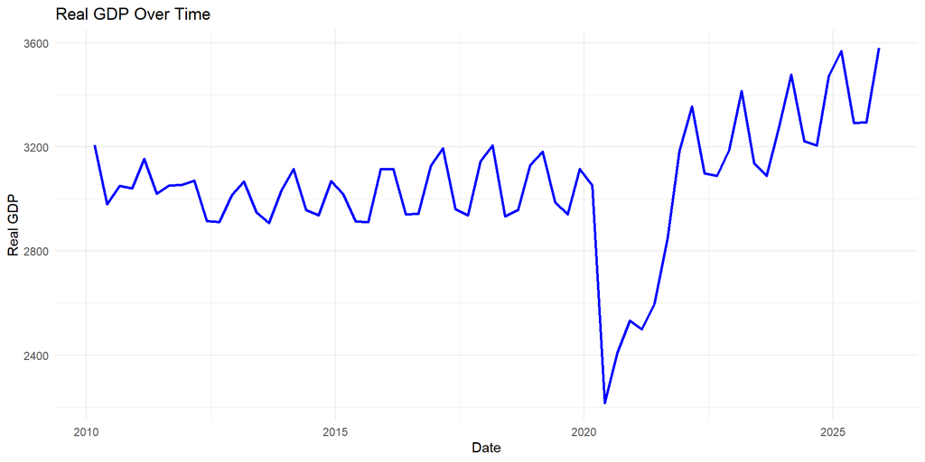

```r
ggplot(gdp_bb, aes(x = date, y = gdp)) +
  geom_line(color = "blue", linewidth = 1) +
  labs(title = "Real GDP Over Time",
       x = "Date", y = "Real GDP") +
  theme_minimal()
```

# ggplot2 — density plot

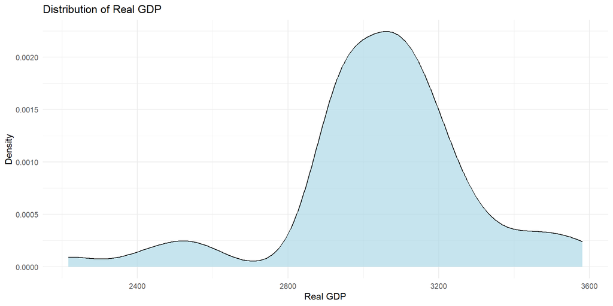

```r
ggplot(gdp_bb, aes(x = gdp)) +
  geom_density(fill = "lightblue", alpha = 0.7) +
  labs(title = "Distribution of Real GDP",
       x = "Real GDP", y = "Density") +
  theme_minimal()
```

# ggplot2 — scatter plot

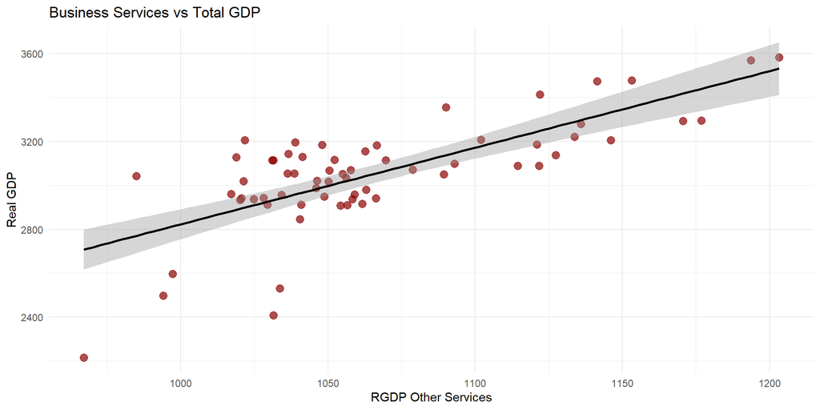

```r
ggplot(gdp_bb, aes(x = gdp_business_other_services, y = gdp)) +
  geom_point(color = "darkred", size = 3, alpha = 0.7) +
  geom_smooth(method = "lm", se = TRUE, color = "black") +
  labs(title = "Business Services vs Total GDP",
       x = "RGDP Other Services", y = "Real GDP") +
  theme_minimal()
```

# Activity 4

**Create a scatter plot of GDP vs S&P 500**

```r
ggplot(bb_data, aes(y = ___, x = ___)) +
  geom_point(color = "darkred", size = 3, alpha = 0.7) +
  geom_smooth(method = "lm", se = TRUE, color = "black") +
  labs(title = "S&P 500 and Barbados GDP",
       x = "S&P 500", y = "Real GDP") +
  theme_minimal()
```

# Activity 4 — Solution

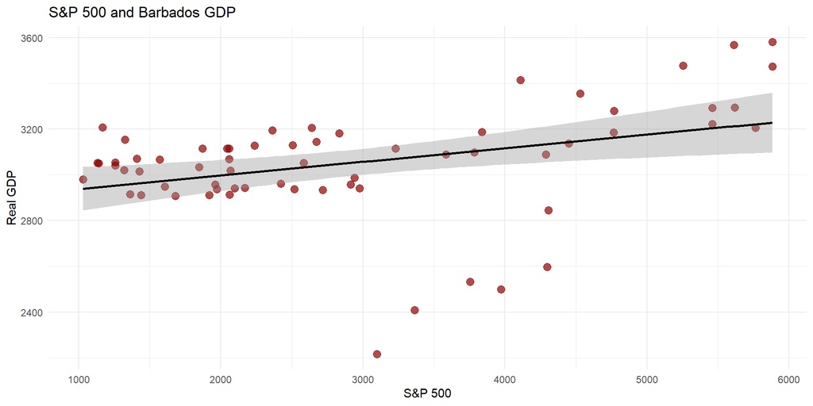

```r
ggplot(bb_data, aes(y = gdp, x = sp500)) +
  geom_point(color = "darkred", size = 3, alpha = 0.7) +
  geom_smooth(method = "lm", se = TRUE, color = "black") +
  labs(title = "S&P 500 and Barbados GDP",
       x = "S&P 500", y = "Real GDP") +
  theme_minimal()
```